# Regression

## Assessing Goodness of fit

Given the parameter estimates $\hat{\theta}$, we can use the residuals $\hat{\epsilon}$ to check the quality of the regression

$\hat{\epsilon} = y - f(x, \hat{\theta})$

To get the residuals:

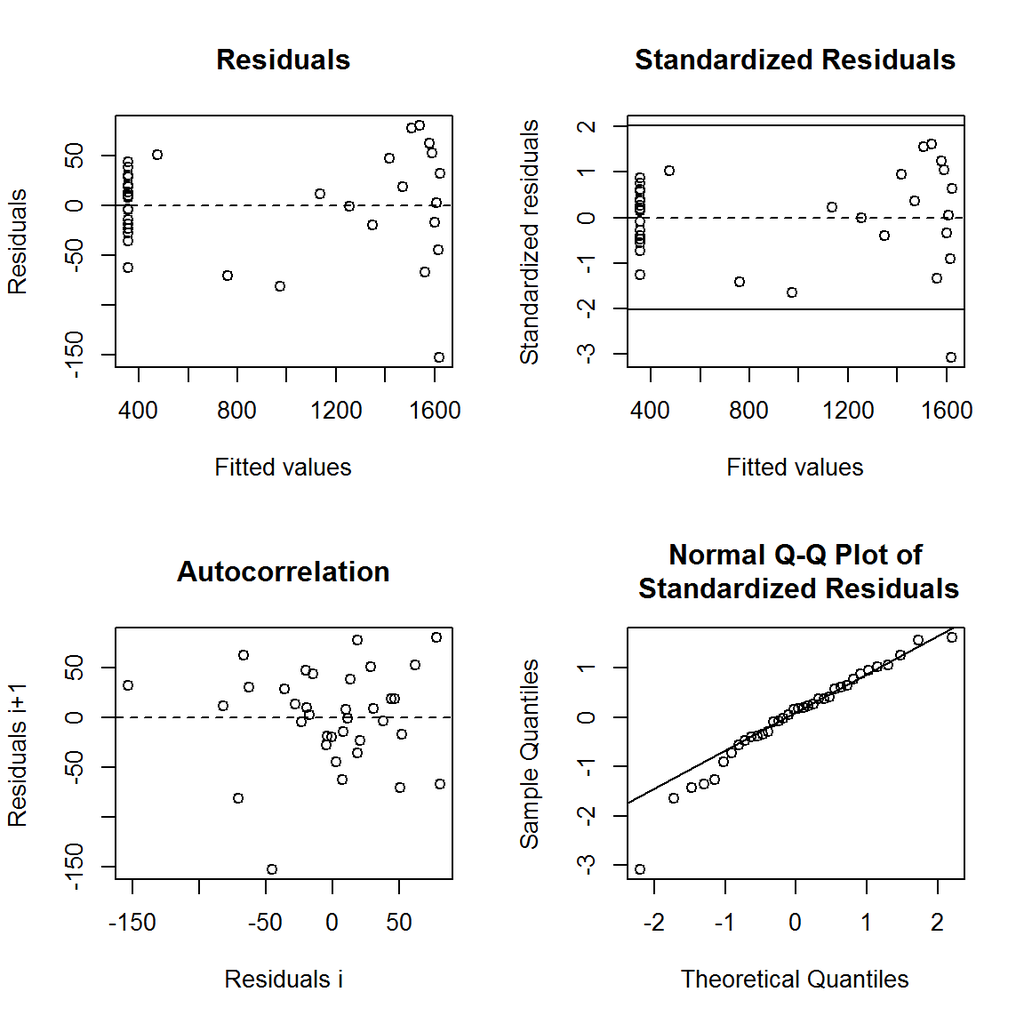

```r
e_hat <- nlsResiduals(fit_O2K)
plot(e_hat)
```

We see that the residuals seem approximately normally distributed, and there’s no evidence of autocorrelation.

```r
test.nlsResiduals(e_hat)
```

```
##
## ------
##  Shapiro-Wilk normality test
##
## data:  stdres
## W = 0.95205, p-value = 0.1214
##
##
## ------
```

```
##
##  Runs Test
##
## data:  as.factor(run)
## Standard Normal = 0.76123, p-value = 0.4465
## alternative hypothesis: two.sided
```

which means the null hypothesis (they are normally distributed) cannot be rejected. The second test cannot reject the hypothesis of no autocorrelation.

The next functions compute confidence regions for the parameters:

```r
O2K.cont1 <- nlsContourRSS(fit_O2K)
```

```
## 0%33%66%100%
##  RSS contour surface array returned
```

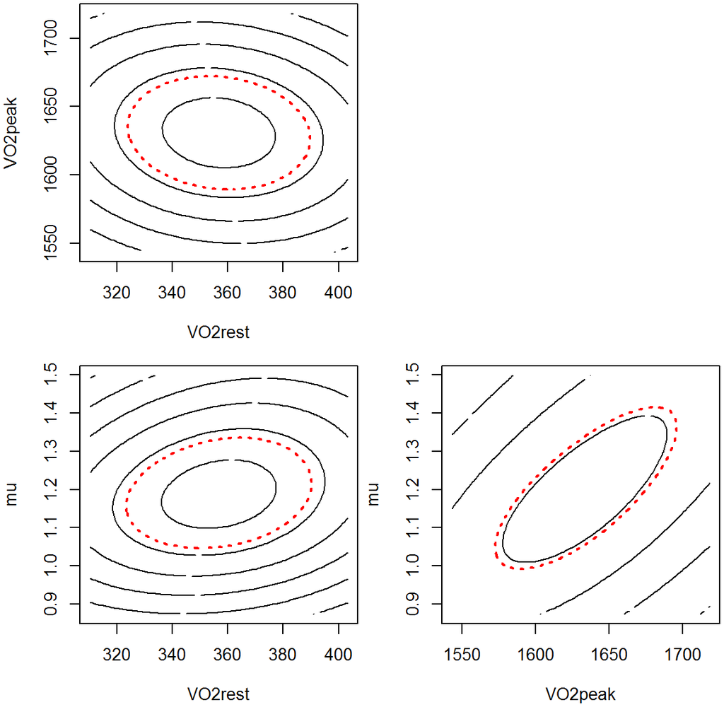

```r
plot(O2K.cont1, col = FALSE, nlev = 5)
```

```r
O2K.conf1 <- nlsConfRegions(fit_O2K, exp = 2, length = 2000)
```

[output not shown]

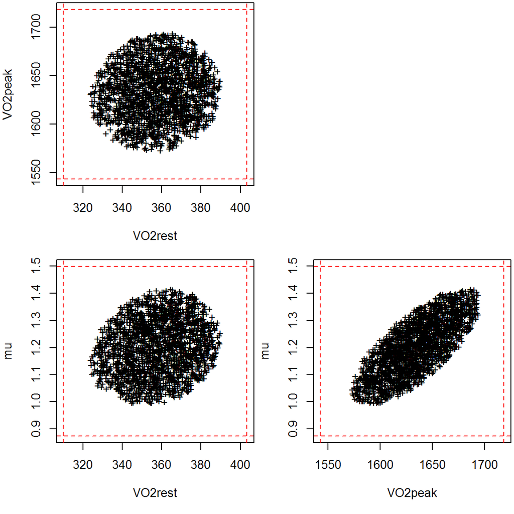

```r
plot(O2K.conf1, bounds = TRUE, pch=20)
```